# Index

Yifan Dai

2/20/2021

# Introduction

Hi! This is my first report about the variable population of Asian American in jail `aapi_jail_pop`, total in jail `total_jail_pop`, Black people in jail `black_jail_pop`, white people in jail `white_jail_pop`, and location `state`. The reason I choose them to analyze are because I want to know is there any **relationship** between *races* in population in jail, what the **ratio** of **population in jail for each race** *verses* **total population in jail** is, and is location a factor of crimes. Therefore, the domain of my interests for this reseach are between population in *jail* for each race and *state*. Here is the link of my data source from vera-institute on github: [incarceration trends](https://github.com/vera-institute/incarceration-trends/blob/master/incarceration_trends.csv?raw=true)

# Summary Information

The *average values* of my variable `aapi_jail_pop` across **all** of counties is 1.9814045.The **highest** `aapi_jail_pop` is 893 at Los Angeles County in 1999, and the **lowest** `aapi_jail_pop` is 0.

# Charts

Below is the **population in jail over time chart** that shows how *Asian American, Black, White, and Total* population in jail changed over **1970-2018**. It can tell me the **trends** for those races over time and compare to each other. As shown below, the population of white in jail *surpassed* black in jail in **2000**. The population of Asian in jail around **0** over time, probably because most of the Asian family are more cautious **not** getting involved into crimes.

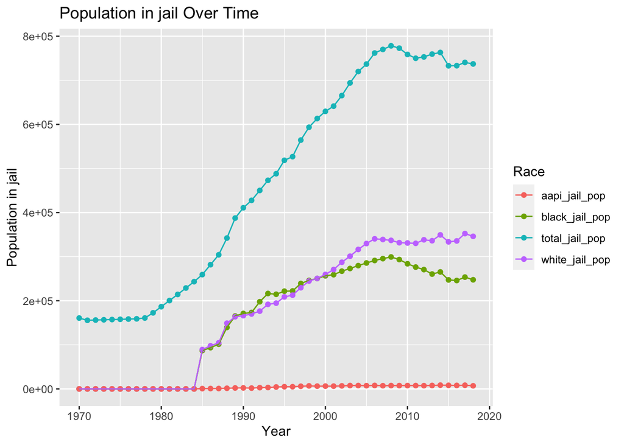

[figure not shown]

The third and last chart I created is the map of *the ratio of Asian American in jail : Total in jail in the United States*. The lighter red it colored, the bigger ratio it is, and vice. The top states that has the **most** Asian American in jail:Total in jail are locating at *Minnesota, Washington, Utah.*

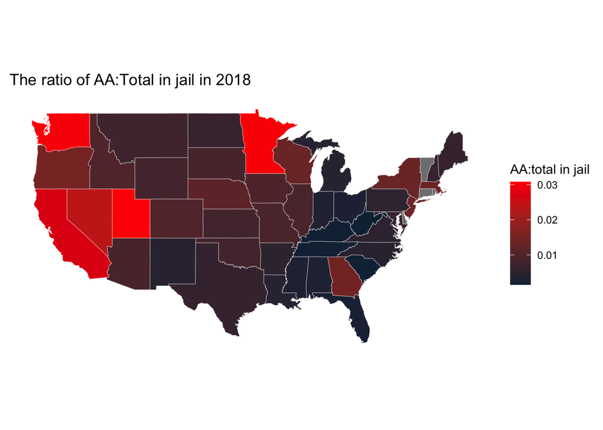